# Structural Divergence Analysis

Maria Laura Marcos, Julian Echave

# Introduction

We study the evolutionary divergence of proteins using the LF-ENM and comparing simulated mutants with experimental data.

In this case we studied the serinProteases family. We used the ENM ANM with R0 = 7.5 to generate mutants. We used as reference for the ENM the protein with pdb code 1mcta. The active/functional sites of the reference are:

```
##   active.site.index                       description
## 1                48 charge relay system - active site
## 2                92 charge relay system - active site
## 3               179   required for specificity - site
## 4               185 charge relay system - active site
```

We simulated 10 mutants of this reference for each protein of the family. The serinProteases family is of the type beta and consists of the following proteins:

```
##  [1] "1bbr"  "1ppb"  "1hcga" "1kigh" "1fxya" "2ptn"  "1trma" "1a0ja"
##  [9] "2tbs"  "1ab9"  "1ton"  "2pka"  "1npma" "1azza" "3est"  "1a0la"
## [17] "1lmwb" "1a5ia" "1a5ha" "1fuja" "1hnee" "1a7s"  "3rp2a" "1klt"
## [25] "1dfpa" "1sgt"
```

# Structural divergence along sites

Here we study how structural divergence varies from site to site. We compare simulated data with empirical data.

### Mean z.RSD vs site

To measure structural divergence we use z.RSD profiles, which are the best for most families.

The following plot compares the mean z.RSD profiles, including standard errors (with .999 confidence level for the mean) *Warning: the effective number of data should be smaller than the actual data, especially for the experimental dataset because of several factors. We need to deal with this for quantitative analysis. Probably we’ll need to use bootstrapping to calculate standard errors non-parametrically*

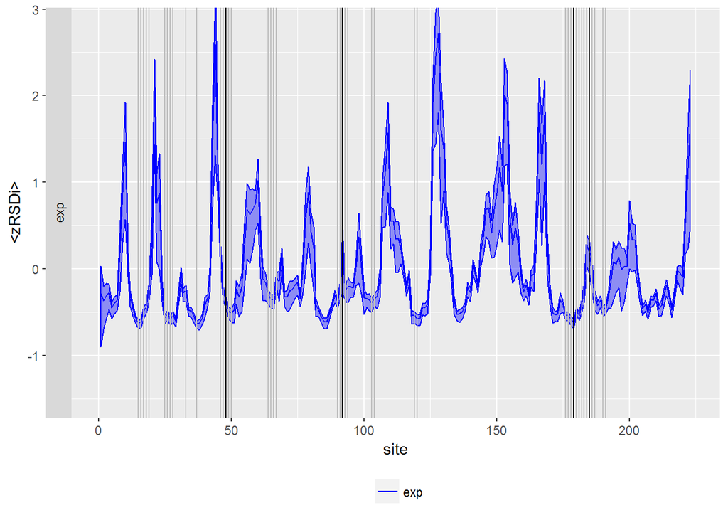

Black lines are the active sites and grey lines are their contacts

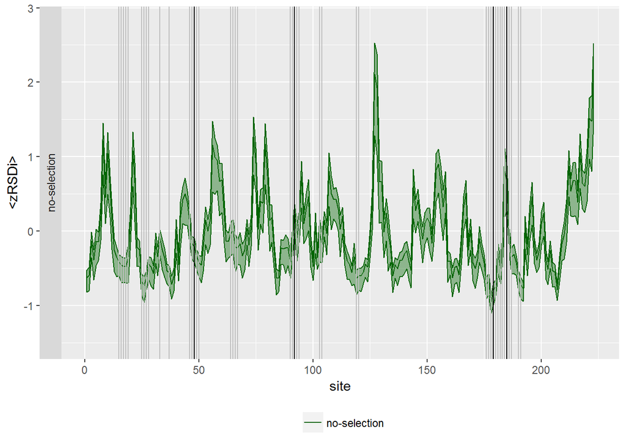

Black lines are the active sites and grey lines are their contacts

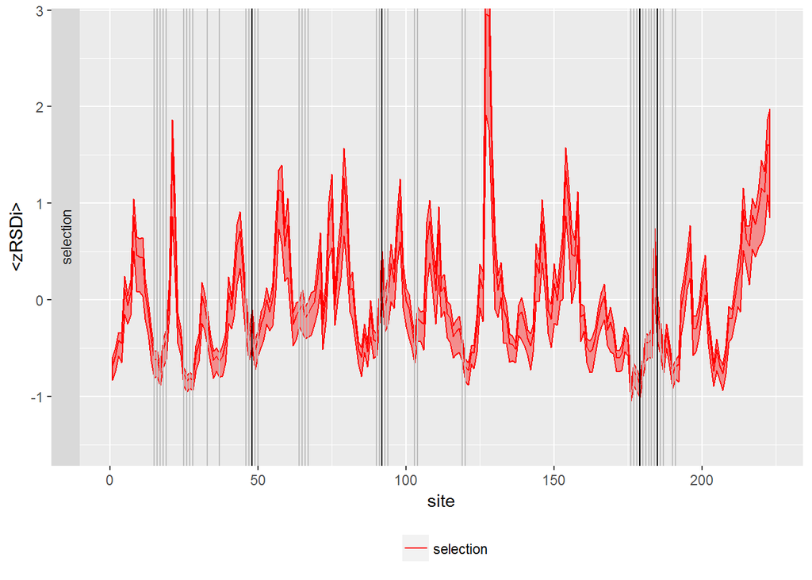

Black lines are the active sites and grey lines are their contacts

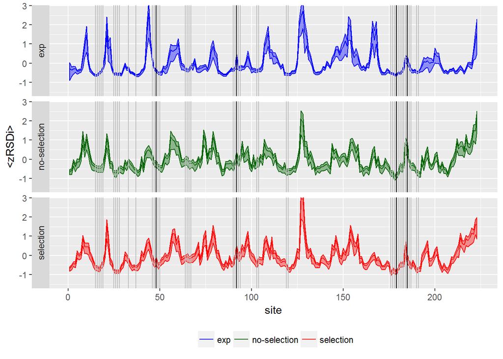

Black lines are the active sites and grey lines are their contacts

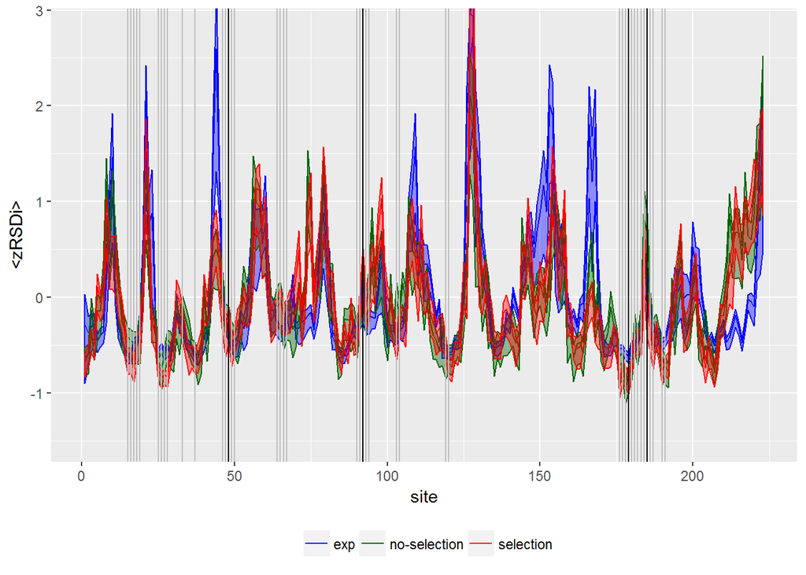

Black lines are the active sites and grey lines are their contacts

### Correlation between profiles

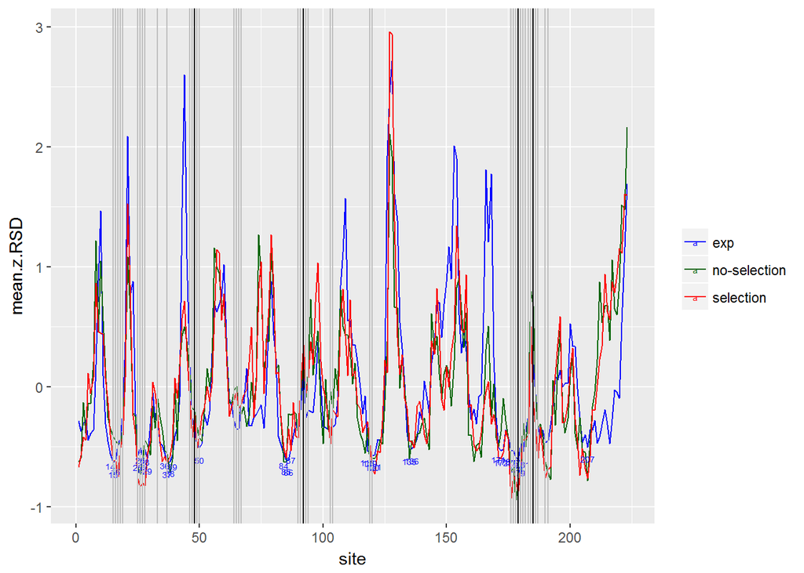

Correlation between profiles

| comparison | R |
| --- | --- |
| exp vs mut | 0.67 |
| exp vs strong | 0.70 |
| mut vs strong | 0.91 |

### Comparison between profiles

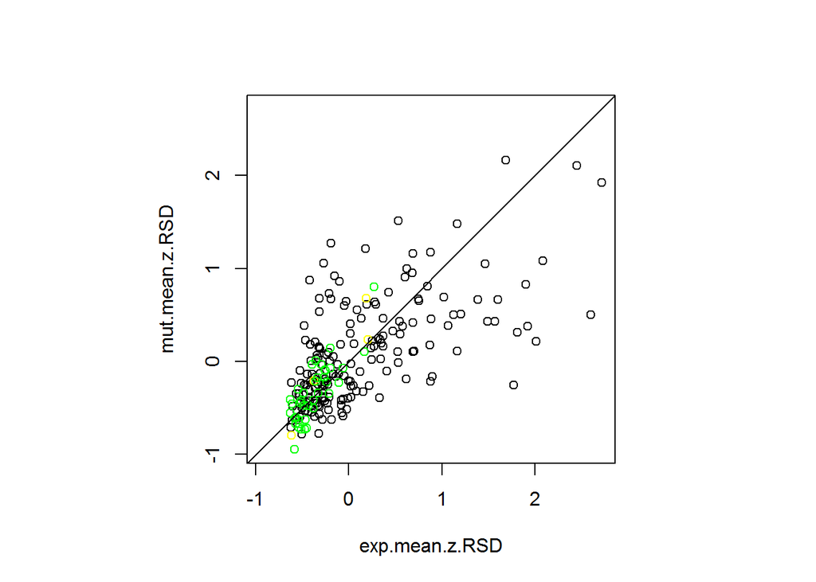

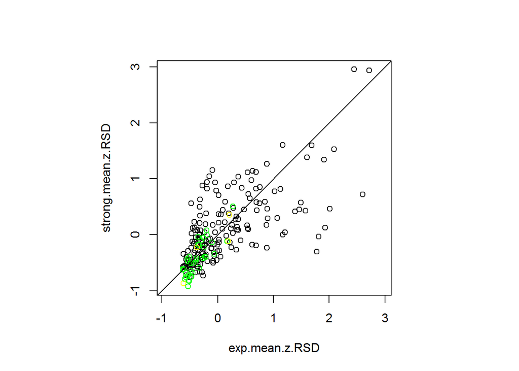

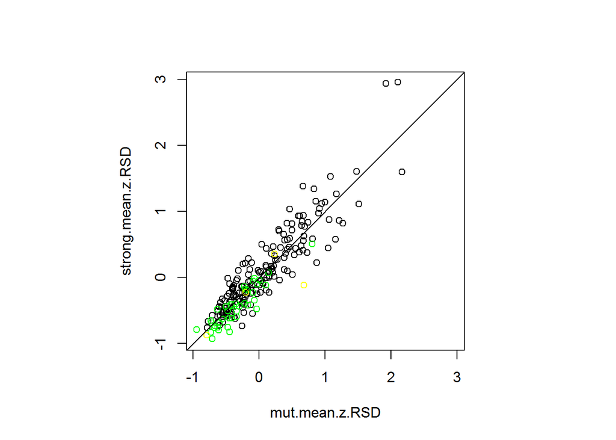

### Distances to the active sites

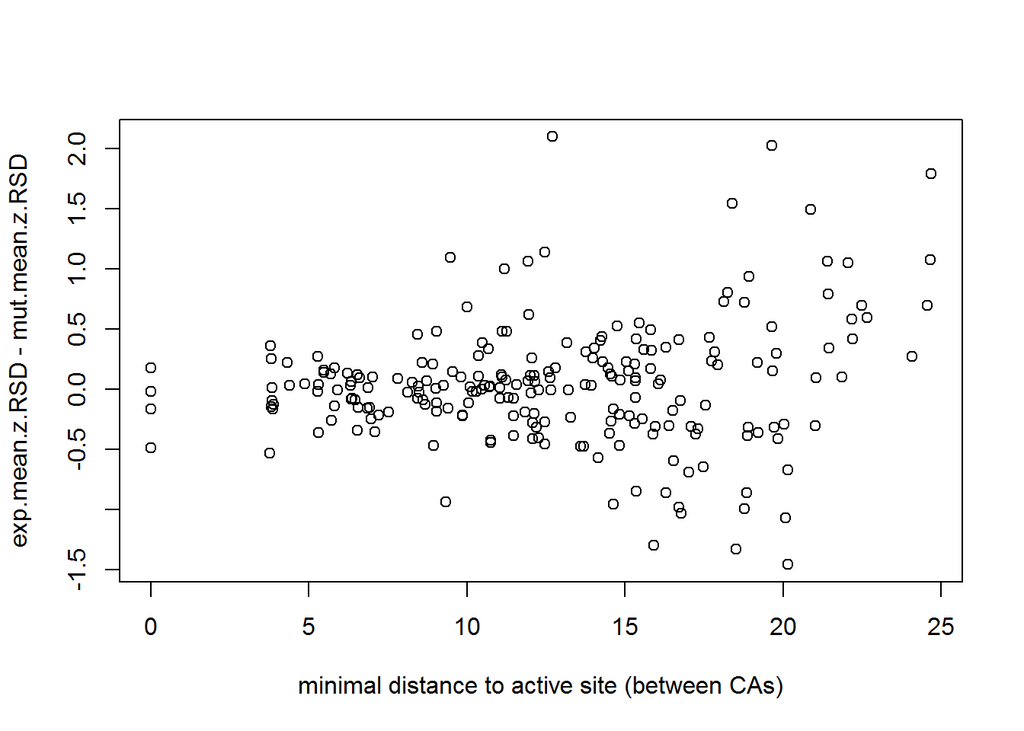

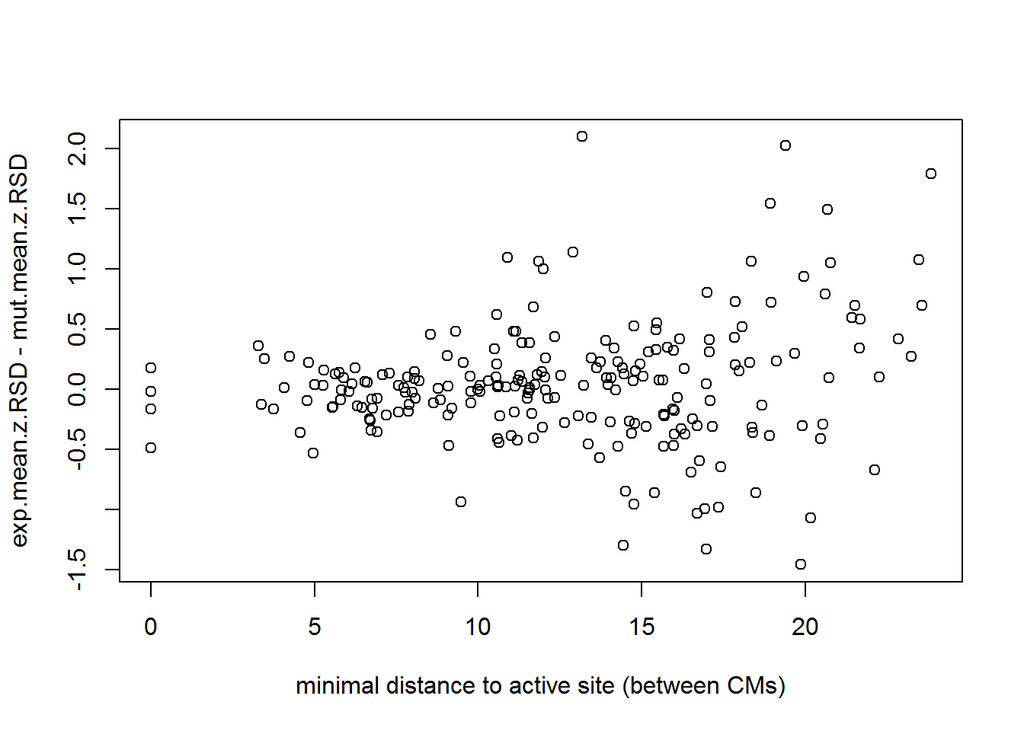

Correlation between differences in profiles and the minimal distance to the active site

| comparison | R |
| --- | --- |
| (exp - mut) vs min.da.CA | 0.15 |
| (exp - mut) vs min.da.CM | 0.15 |

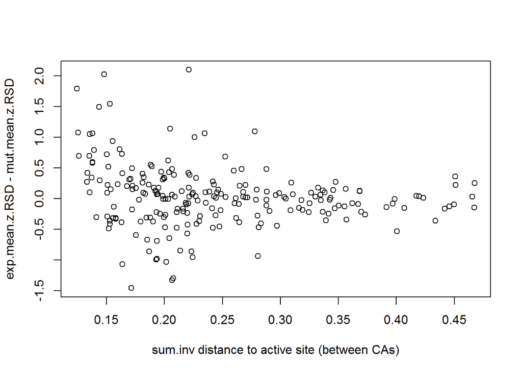

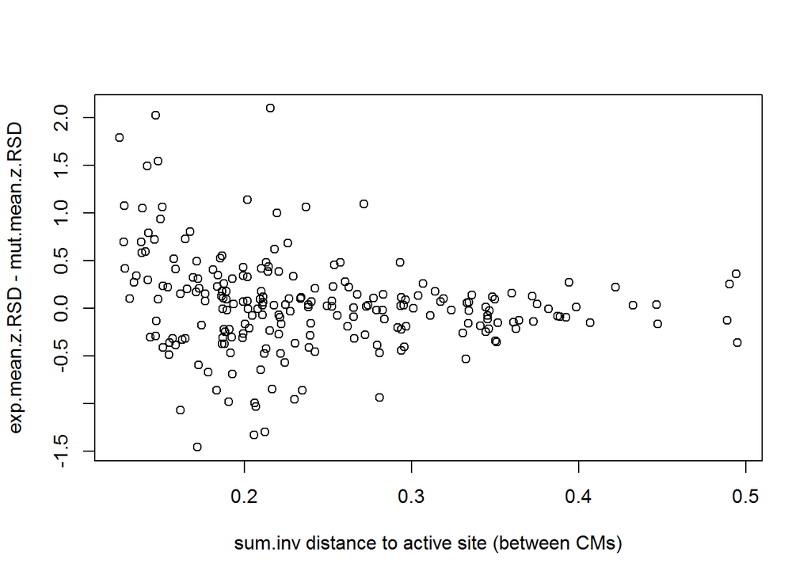

Correlation between differences in profiles and the sum.inv distance to the active site

| comparison | R |
| --- | --- |
| (exp - mut) vs sum.inv.da.CA | -0.18 |
| (exp - mut) vs sum.inv.da.CM | -0.18 |

Correlation between CN and the minimal distance to the active site

| comparison | R |
| --- | --- |
| CN vs min.da.CA | -0.47 |
| CN vs min.da.CM | -0.49 |

Correlation between CN and the sum.inv distance to the active site

| comparison | R |
| --- | --- |
| CN vs sum.inv.da.CA | 0.44 |
| CN vs sum.inv.da.CM | 0.44 |

### sequence comparison

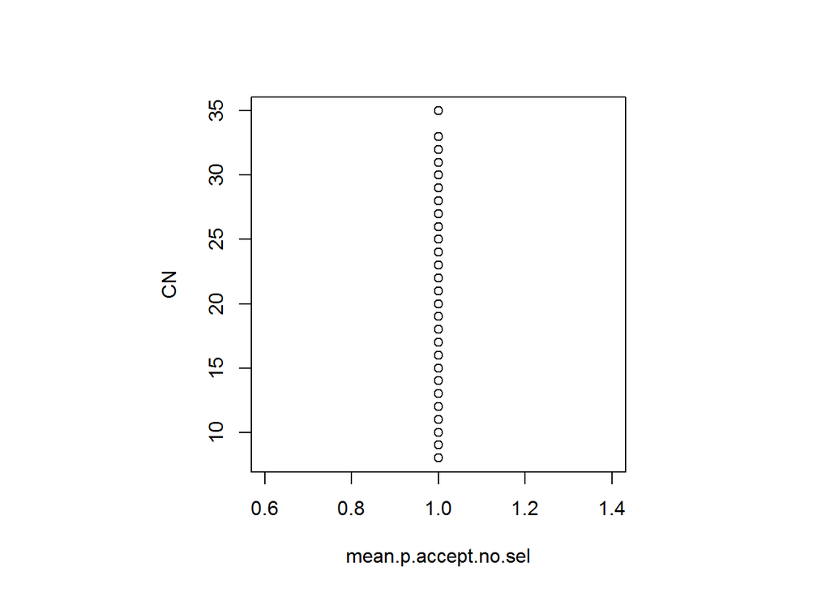

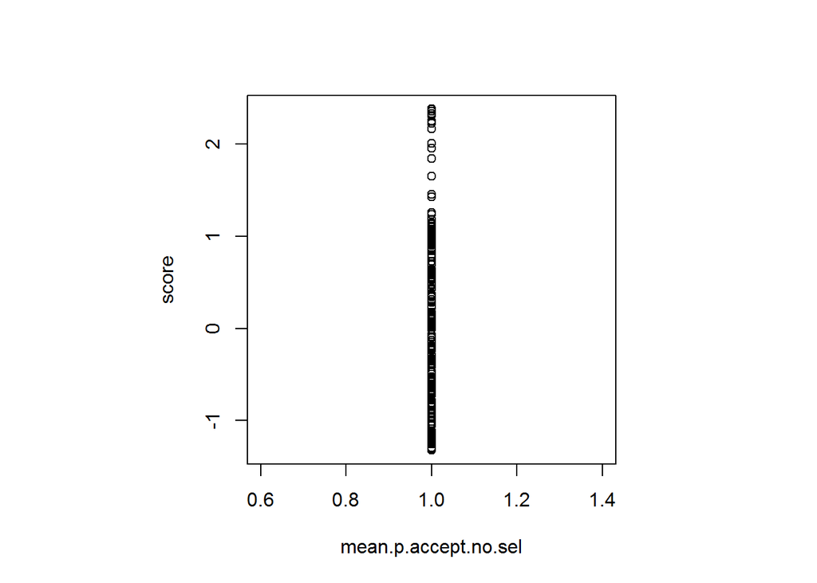

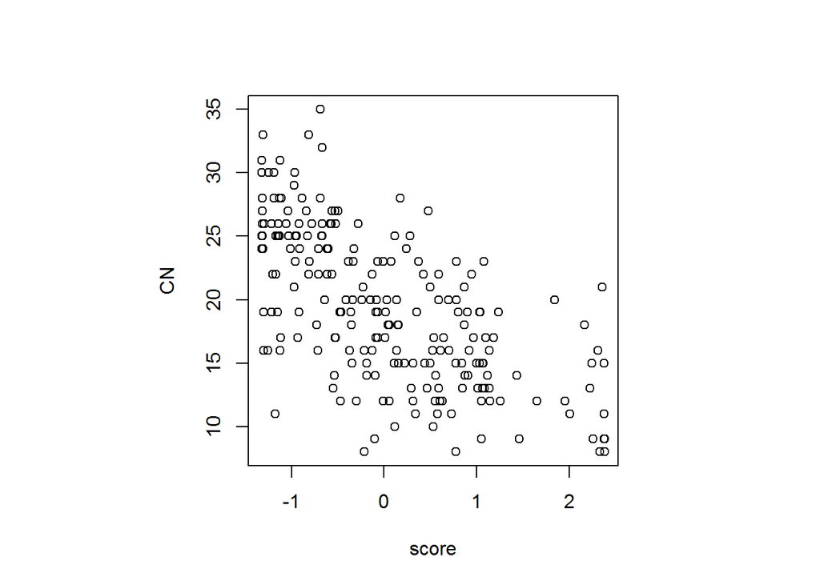

Correlation between sequence profiles

| comparison | R |
| --- | --- |
| p.accept.no.sel vs CN | NA |
| p.accept.no.sel vs score | NA |
| score vs CN | -0.65 |

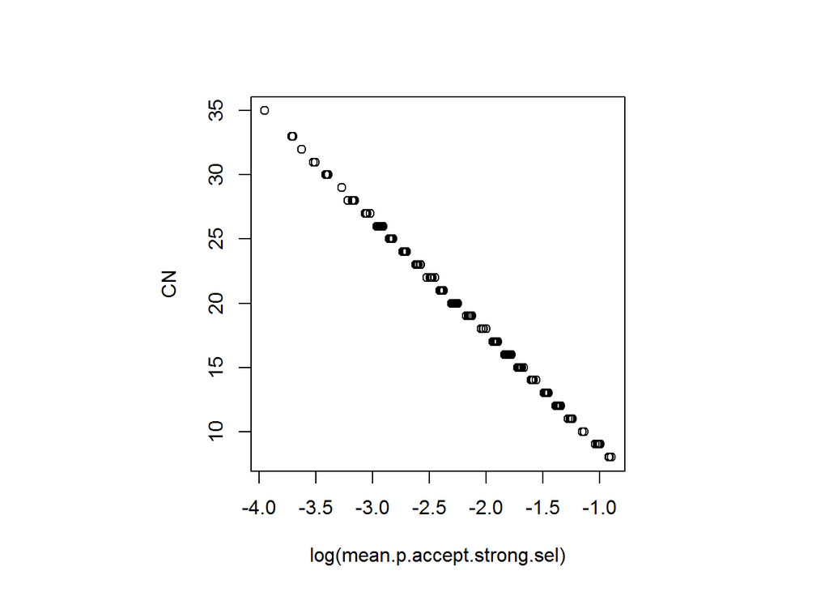

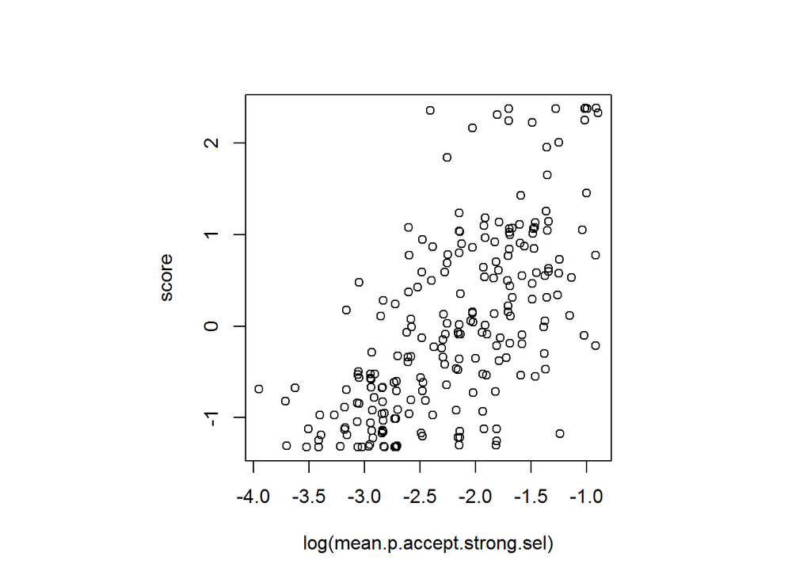

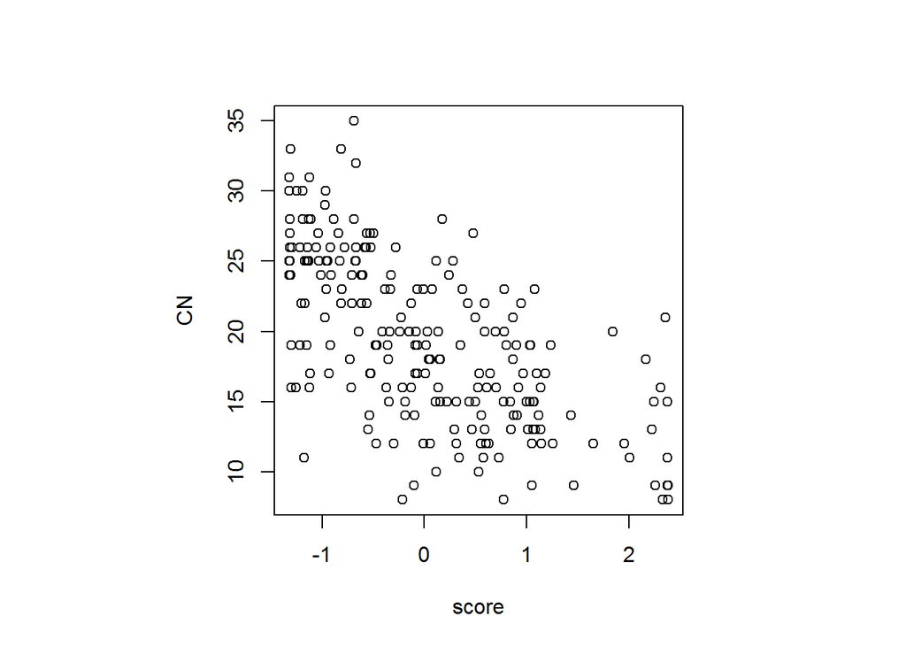

Correlation between sequence profiles

comparison

R

log(p.accept.strong.sel) vs CN

-1.00

log(p.accept.strong.sel) vs score

0.65

score vs CN

-0.65

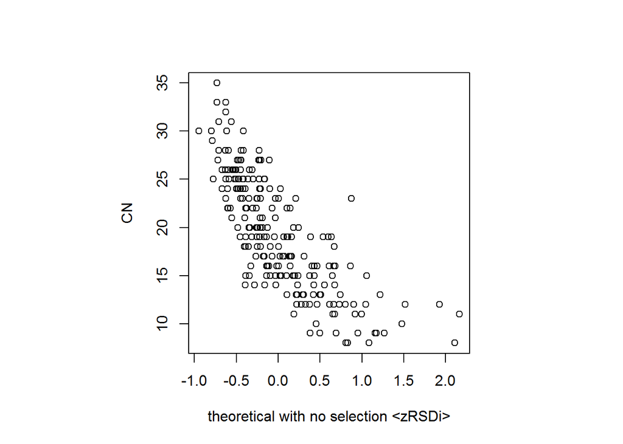

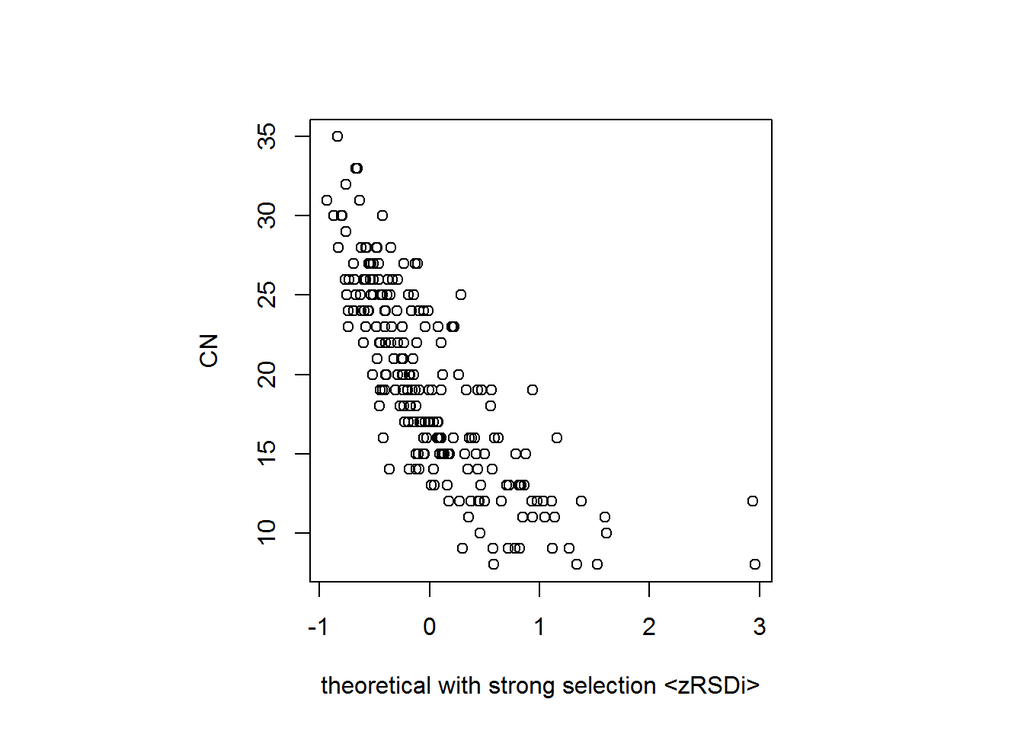

Correlation structure - sequence

| comparison | R |
| --- | --- |
| exp.mean.z.RSD vs CN | -0.62 |
| mut.mean.z.RSD vs CN | -0.78 |
| strong.mean.z.RSD vs CN | -0.78 |